# pixelclassifier tutorial

This notebook illustrates how to use pixelclassifier to highlight cell contours by training a model with 'contour' versus 'non-contour' labels.

We start with some general imports.

```python
import numpy as np
import matplotlib.pyplot as plt
from gpfunctions import generateSynthCellsImage, imshow, imshowlist, \
    imerode, imdilate, tifwrite, im2double, tifread, stack2list, createFolderIfNonExistent
%matplotlib inline
```

We will generate some synthetic data: 5 [image, label] pairs for training, and 1 [image, label] pair for testing. Notice that the labels are 'class balanced', i.e. in each image the number of contour pixels is roughly the same as the number of non-contour pixels.

```python
train_folder = 'DataForPC/Train'
test_folder = 'DataForPC/Test'
createFolderIfNonExistent(train_folder)
createFolderIfNonExistent(test_folder)

def gen_img_lbl_pair():
    I, L = generateSynthCellsImage()

    cells = imdilate(L > 0, 1)
    interior = imerode(cells, 2)
    contours = np.logical_and(cells, np.logical_not(interior))
    not_contours = np.logical_not(contours)

    c_cont = np.sum(contours)

    f = c_cont/np.sum(not_contours)
    not_contours = np.logical_and(not_contours, np.random.rand(I.shape[0], I.shape[1]) < f)

    print('n pixels class 0:', np.sum(contours), '| npixels class 1:', np.sum(not_contours))

    L[:] = 0
    L[contours] = 1
    L[not_contours] = 2

    return I, L

for idx in range(5):
    print('train image', idx)

    I, L = gen_img_lbl_pair()
    tifwrite(np.uint8(255*I), '%s/I%05d_Img.tif' % (train_folder, idx))
    tifwrite(L, '%s/I%05d_Ant.tif' % (train_folder, idx))

for idx in range(1):
    print('test iamge', idx)

    I, L = gen_img_lbl_pair()
    tifwrite(np.uint8(255*I), '%s/I%05d_Img.tif' % (test_folder, idx))
    tifwrite(L, '%s/I%05d_Ant.tif' % (test_folder, idx))
```

```
train image 0
n pixels class 0: 17888 | npixels class 1: 17952
train image 1
n pixels class 0: 18268 | npixels class 1: 18206
train image 2
n pixels class 0: 18020 | npixels class 1: 17982
train image 3
n pixels class 0: 18152 | npixels class 1: 17987
train image 4
n pixels class 0: 18442 | npixels class 1: 18370
test iamge 0
n pixels class 0: 18152 | npixels class 1: 18151
```

Let's take a look at the test pair.

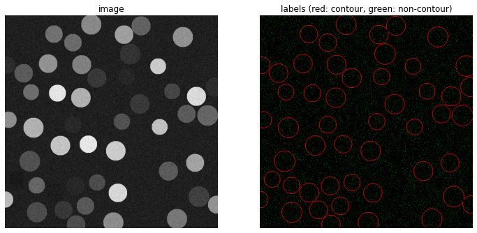

```python
I = tifread('%s/I%05d_Img.tif' % (test_folder, 0))
L = tifread('%s/I%05d_Ant.tif' % (test_folder, 0))

plt.figure(figsize=(12, 6))

plt.subplot(1,2,1)
plt.imshow(I, cmap='gray'); plt.axis('off'); plt.title('image');

plt.subplot(1,2,2)
red = L == 1
green = L == 2
blue = np.zeros(L.shape, L.dtype)
rgb = 255*np.stack([red, green, blue], axis=2)
plt.imshow(rgb); plt.axis('off'); plt.title('labels (red: contour, green: non-contour)');
```

To train a Random Forest model via pixelclassifier we simply pass the path to the training set as well as scale parameters for derivatives and LoG filters. We expect derivatives to be sufficient, so we pass an empty list as the sigmaLoG parameter. Once the model is done training, a plot of feature importances is shown.

```
training...
...done
elapsed time:  10.350951433181763
```

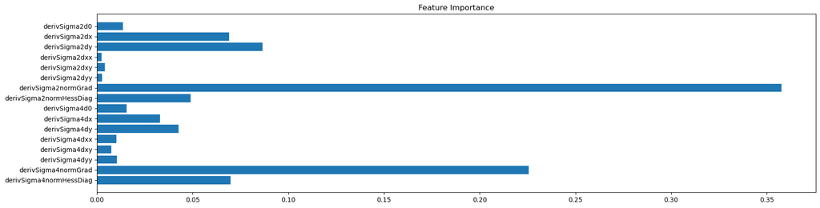

```python
import pixelclassifier as pc

trainPath = 'DataForPC/Train'
model = pc.train(trainPath,sigmaDeriv=[2,4],sigmaLoG=[])

pc.plotFeatImport(model['featImport'],model['featNames'])
```

Let's now see how the model performs on the test image. We can ask the classifier for either class or probability map outputs.

```
classifying...
...done
elapsed time:  0.8567202091217041
classifying...
...done
elapsed time:  0.8872902393341064
```

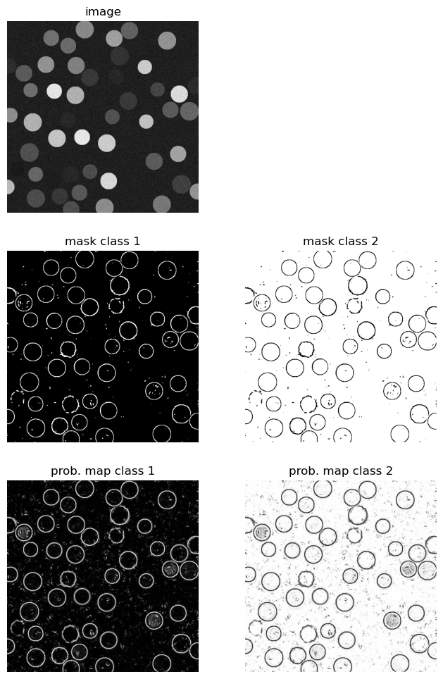

```python
path = 'DataForPC/Test/I00000_Img.tif'
I = im2double(tifread(path))

C = pc.classify(I,model,output='classes')
P = pc.classify(I,model,output='probmaps')


plt.figure(figsize=(8, 12))

plt.subplot(3,2,1)
plt.imshow(I, cmap='gray'); plt.axis('off'); plt.title('image');

plt.subplot(3,2,3)
plt.imshow(C[:,:,0], cmap='gray'); plt.axis('off'); plt.title('mask class 1');

plt.subplot(3,2,4)
plt.imshow(C[:,:,1], cmap='gray'); plt.axis('off'); plt.title('mask class 2');

plt.subplot(3,2,5)
plt.imshow(P[:,:,0], cmap='gray'); plt.axis('off'); plt.title('prob. map class 1');

plt.subplot(3,2,6)
plt.imshow(P[:,:,1], cmap='gray'); plt.axis('off'); plt.title('prob. map class 2');
```